# Channel Classification Analysis

In this document we take a closer look at our classification of channels by political leaning. We have two methods of classifying channels:

1. Match channel names against bias ratings of news outlets. We use media bias ratings from three sources and construct a final bias classification via majority vote.
   - Media Bias Fact Check (www.mediabiasfactcheck.com): a leading classifier of the U.S. media landscape. Classifies outlets as extreme-left, left, center-left, center, center-right, right, or extreme right. We collapse this scale to left, center, and right.
   - AdFontes (www.adfontesmedia.com): assigns media outlets polarity and factuality scores. Polarity is an integer rating where a negative score indicates a left-leaning outlet and a positive score indicates a right-leaning outlet. For our purposes we ignore the continuous scale and use the sign of the rating to classify outlets as left- or right-biased.
   - AllSides (www.allsides.com): a news website that crowdsourced bias classifications of media outlets. Bias ratings are “based on blind surveys of people across the political spectrum, multi-partisan analysis and other in-depth analyses as well as tens of thousands of user ratings.” Outlets are classified as left, center-left, center, right-center, or right. As with MBFC we collapse this scale to left, right, or center.
2. Use comments (@Jan has more details on this) as a proxy for audience, and classify channels as left or right based on the left- and right-share of their commenters.

# Summaries

First a summary table: how many R/L/C/missing channels do we have that we match to channels we visited?

| leaning | n_base | n_alt | share_base | share_alt |
| --- | --- | --- | --- | --- |
| C | 80 | 0 | 0.9% | 0.0% |
| L | 79 | 22 | 0.9% | 0.2% |
| R | 123 | 18 | 1.3% | 0.2% |
| unclassified | 8837 | 9079 | 96.9% | 99.6% |

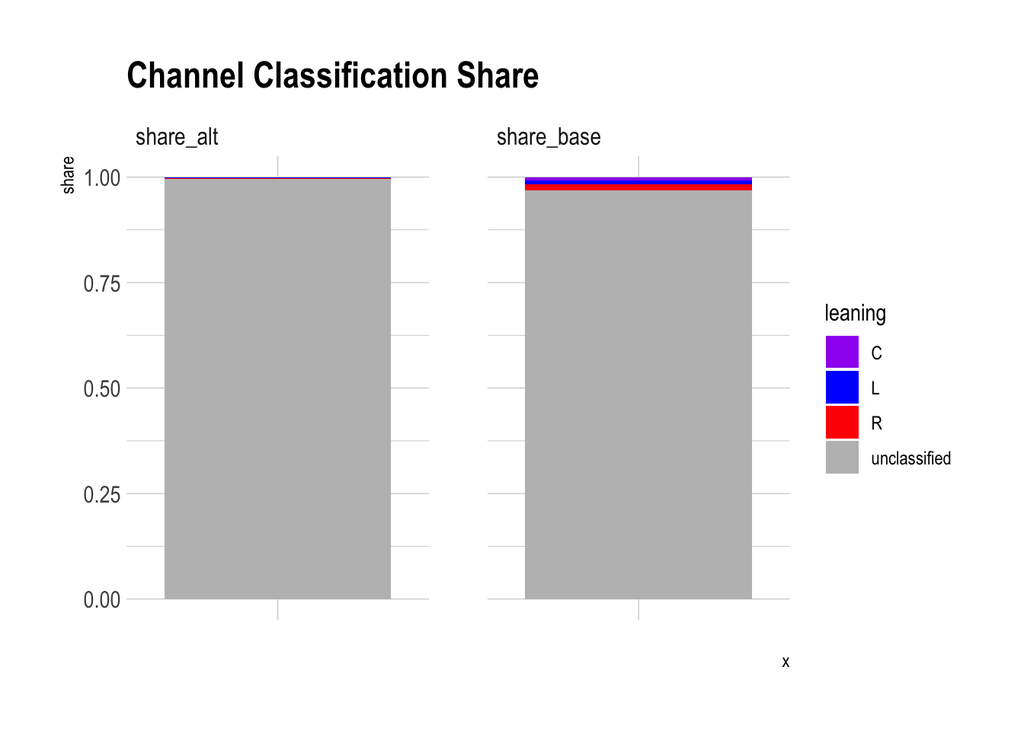

What if we take into account the number of videos we have from each? R/L/C/missing weighted by number of videos from each channel.

| leaning | n_base | n_alt | share_base | share_alt |
| --- | --- | --- | --- | --- |
| C | 1460 | 0 | 2.5% | 0.0% |
| L | 5751 | 122 | 9.9% | 0.2% |
| R | 4048 | 180 | 6.9% | 0.3% |
| unclassified | 47037 | 57994 | 80.7% | 99.5% |

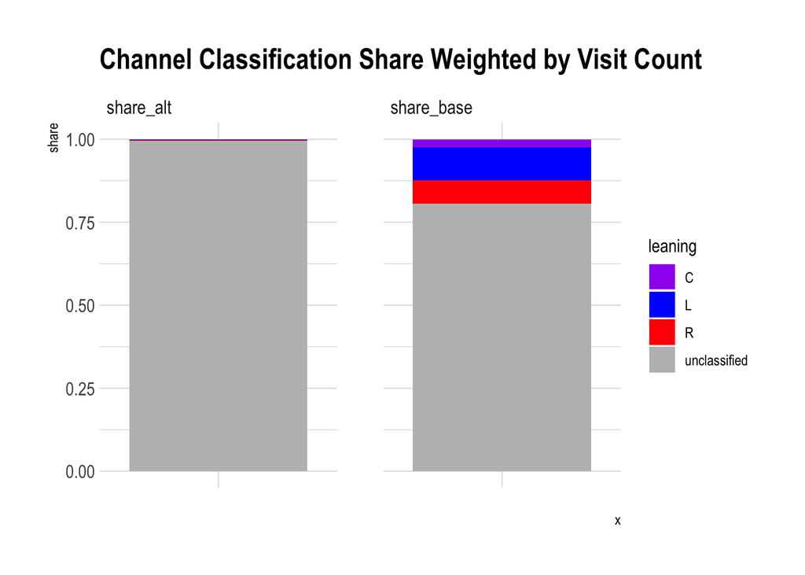

# Channel Classification Comparisons

Do the two classifications line up? Here we are comparing the unmatched classification lists. Clearly there is very little overlap between our two classifications.

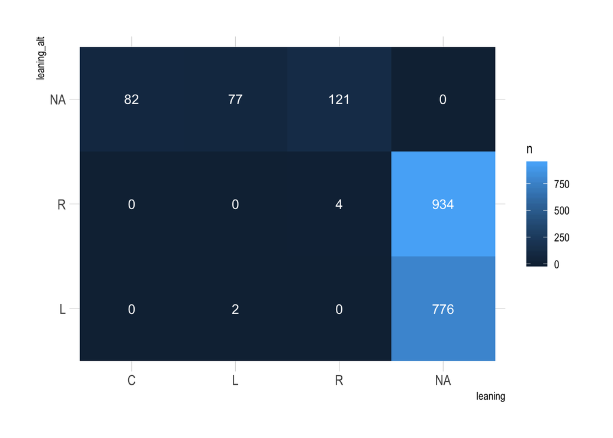

What do the channels in each classification look like? Note that the information for the base and alternative classifications were pulled at different dates (unsure which date the alternative was pulled on).

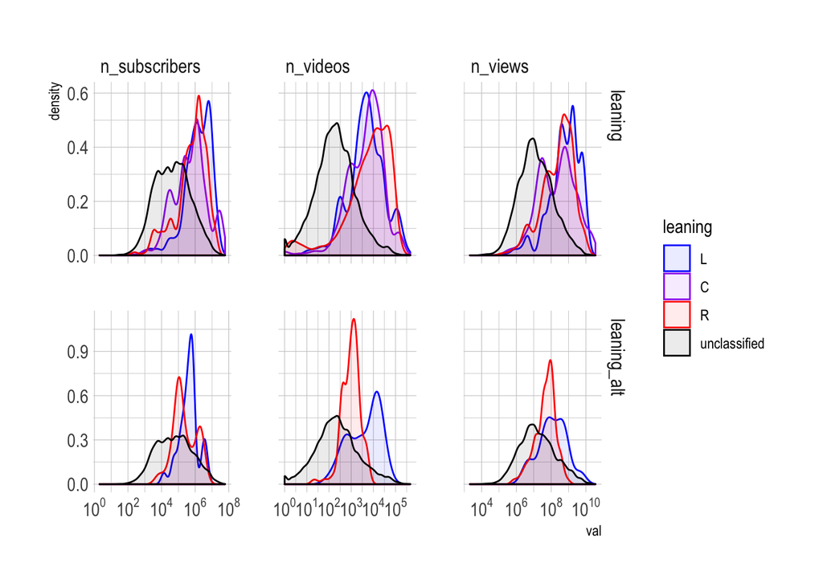

Let’s take a look at the averages.

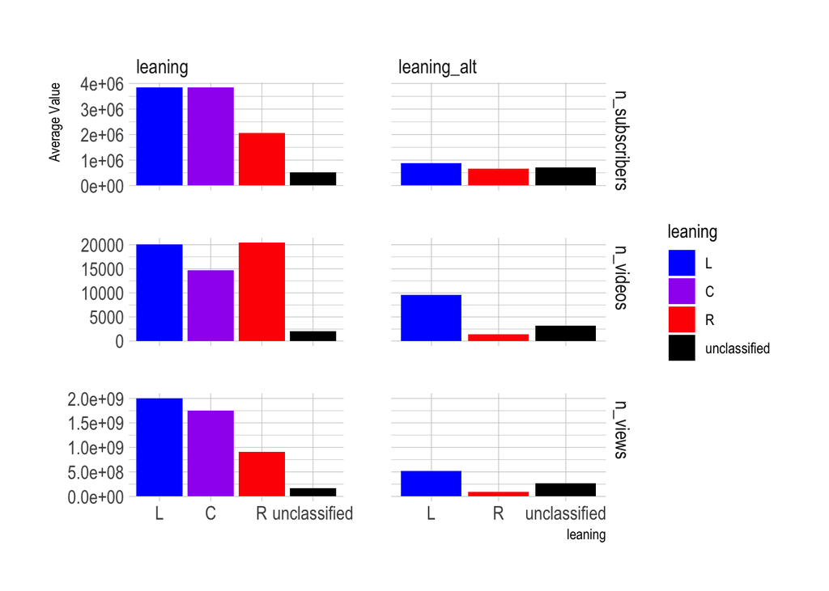